# Exercise Sheet 16

Marco Palma

## Exercise 4

The dataset `crabs` in the package `MASS` contains 5 morphological measurements on 50 crabs each of two colour forms and both sexes.

1. Perform a PCA on the correlation matrix of the morphological measurements.
2. Consider the proportion of variance explained. How many principal components would you retain?
3. Look at the loadings matrix. Can you give an interpretation of the principal components?
4. Plot the scores for the first and the second principal components. What do you observe?
5. Repeat the analysis in d. by using different colors for species and different point character for sex. What do you notice?

### Solutions 4

1. You can find the visual description of the variables in the dataset [here](http://duch.mimuw.edu.pl/~pokar/StatystykaII/DANE/CampbellMahon.pdf).

```r
library(MASS)
data(crabs)
crabs_pca <- princomp(crabs[,-1:-3], cor=TRUE)
```

2. The number of principal components is equal to the number of original variables.

```r
summary(crabs_pca)
```

```
## Importance of components:
##                          Comp.1     Comp.2      Comp.3      Comp.4
## Standard deviation     2.188341 0.38946785 0.215946693 0.105524202
## Proportion of Variance 0.957767 0.03033704 0.009326595 0.002227071
## Cumulative Proportion  0.957767 0.98810400 0.997430593 0.999657664
##                              Comp.5
## Standard deviation     0.0413724263
## Proportion of Variance 0.0003423355
## Cumulative Proportion  1.0000000000
```

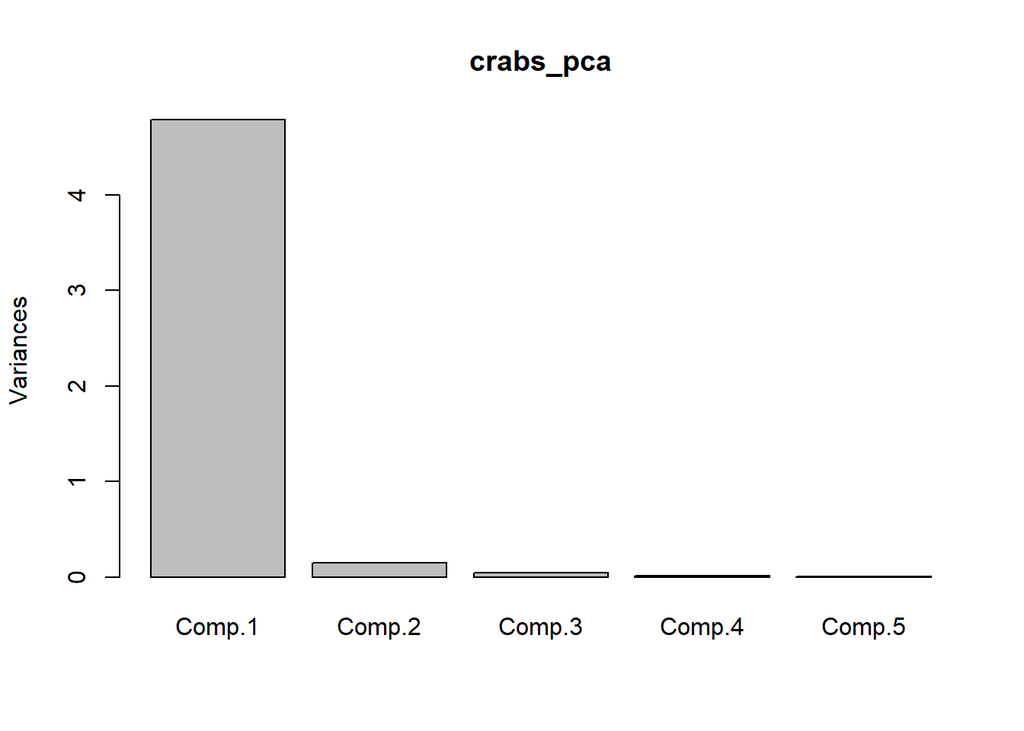

```r
screeplot(crabs_pca)
```

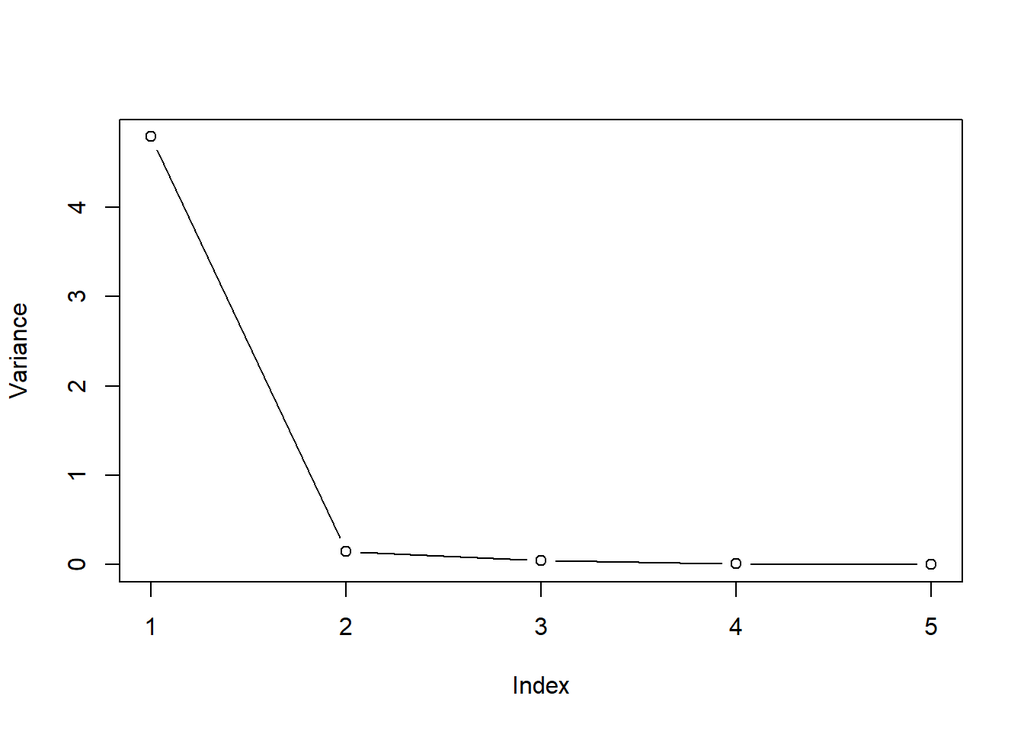

```r
plot(crabs_pca$sdev^2, type = "b", ylab = "Variance")
```

The first principal component (1st PC) accounts for more than 95% of the total variability. If we had to perform dimension reduction, we would have kept only one principal component.

```r
crabs_pca$loadings
```

```
##
## Loadings:
##    Comp.1 Comp.2 Comp.3 Comp.4 Comp.5
## FL  0.452  0.138  0.531  0.697
## RW  0.428 -0.898
## CL  0.453  0.268 -0.310        -0.792
## CW  0.451  0.181 -0.653         0.575
## BD  0.451  0.264  0.443 -0.707  0.176
##
##                Comp.1 Comp.2 Comp.3 Comp.4 Comp.5
## SS loadings       1.0    1.0    1.0    1.0    1.0
## Proportion Var    0.2    0.2    0.2    0.2    0.2
## Cumulative Var    0.2    0.4    0.6    0.8    1.0
```

The loadings for the 1st PC are very similar. Component 1 weights positively all the original variables, therefore we can interpret it as a measure of *size*. The other PCs are negligible and their interpretation is less evident.

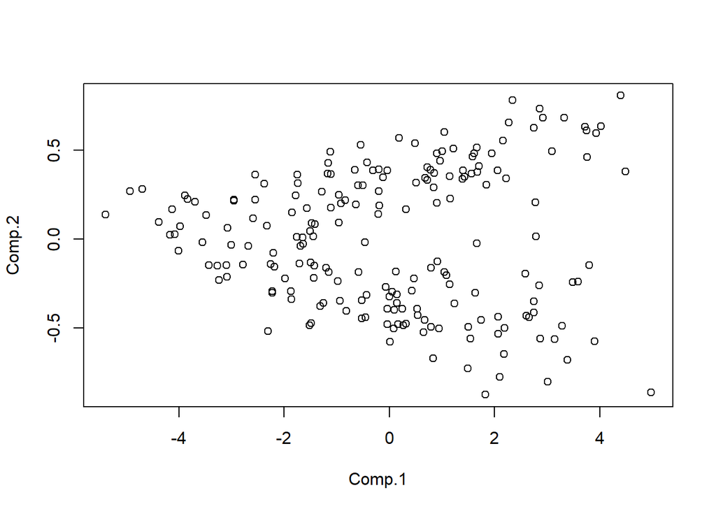

```r
plot(crabs_pca$scores[,1:2])
```

We can see a sort of “<” shape, so there are some crabs with positive values for both PC1 and PC2, some other crabs with positive values for PC1 and negative for PC2 and those with negative values for PC1.

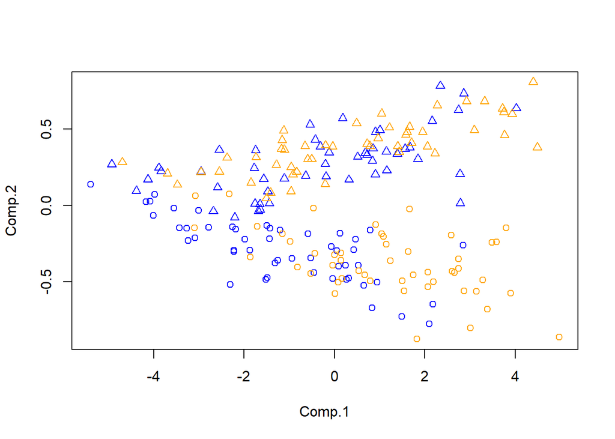

```r
plot(crabs_pca$scores[,1:2], pch = unclass(crabs$sex), col = c("blue", "orange")[unclass(as.numeric(crabs$sp))])
```

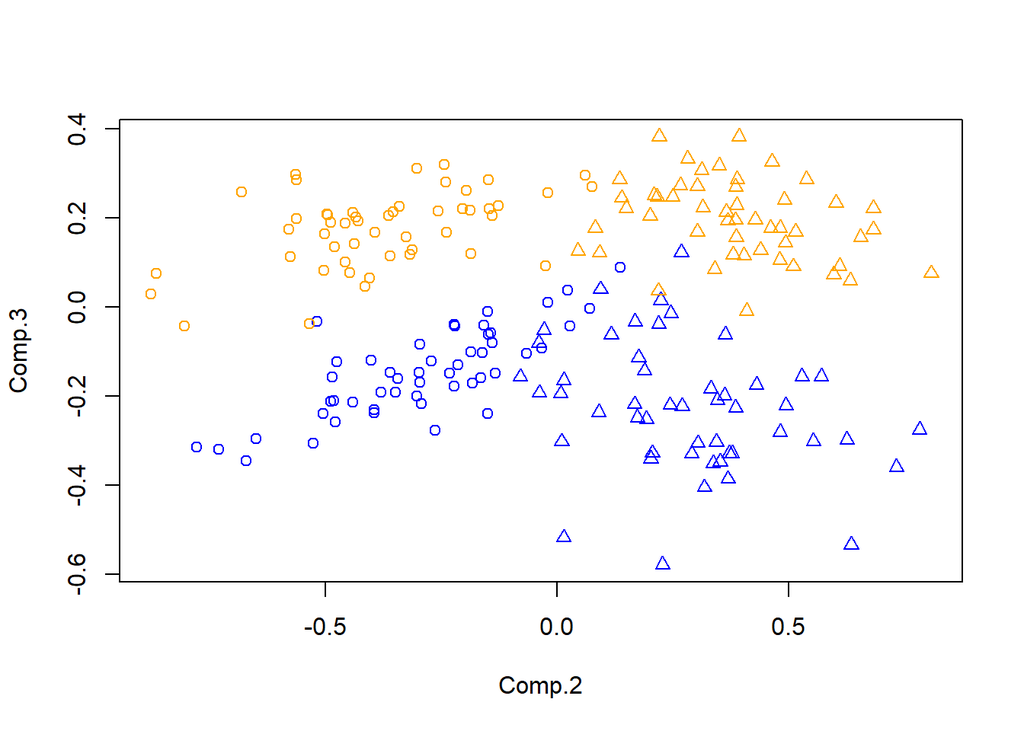

```r
plot(crabs_pca$scores[,2:3], pch = unclass(crabs$sex), col = c("blue", "orange")[unclass(as.numeric(crabs$sp))])
```

It turns out that the second component discriminates pretty well crabs by sex and the third component discriminates between species.

## Exercise 5

The `wellbeing` dataset from the `UsingR` package contains several variables about wellbeing in several European countries (further information about the variables at https://www.prcweb.co.uk/lab/what-makes-us-happy/).

1. Create a subdataset `wellbeing2` with only the countries with no missing data. The rownames should be equal to the names of the countries.
2. Build a dissimilarity matrix for the subdataset (except the wellbeing measure) using the command `dist`.
3. Perform agglomerative hirarchical clustering using `hclust`. Plot the results for different choices of dissimilarity measures and agglomeration methods.
4. Perform $k$-means clustering using the command `kmeans`. Specify different values for $k$. What do you observe?
5. Use the cluster labels obtained using $k$-means with $k=2$ as a covariate in a linear model for the wellbeing measure. Comment on the output.

### Solutions 5

```r
library(UsingR)
wellbeing2 <-wellbeing[complete.cases(wellbeing),]
rownames(wellbeing2) <- wellbeing2$Country
```

```r
eucl_dist <- dist(wellbeing2[,-1:-2], method = "euclidean")
eucl_dist
```

```
##                   Austria    Belgium    Denmark    Finland     France
## Belgium         1665.3485
## Denmark         6240.0292  7896.2393
## Finland         2431.0179  3540.7585  5339.3819
## France          3065.2668  1404.1164  9279.9792  4665.9194
## Germany         1761.7774   499.9272  7940.1823  3832.0415  1503.5035
## Hungary        20326.8115 18674.4394 26543.6803 21821.1433 17311.8428
## Ireland         4503.3164  6161.4137  1737.7870  3794.2516  7548.1034
## Netherlands      804.0608  1706.5091  6409.8222  2939.8043  3032.4556
## Norway         15956.7050 17497.7624 10342.1420 14132.4606 18759.1539
## Poland         20669.1990 19021.4583 26876.8144 22198.4370 17666.3800
## Portugal       14479.6838 12830.2389 20695.8133 16025.8101 11475.4412
## Spain          10116.2805  8460.9517 16327.6133 11648.2151  7096.9323
## Sweden          6781.8096  8298.0443  2678.4537  4969.5568  9561.6009
## Switzerland    11713.4896 13368.0544  5492.7480 10520.4496 14744.4013
## United Kingdom  2764.7183  4415.2430  3487.1978  2559.9661  5801.8478
##                   Germany    Hungary    Ireland Netherlands     Norway
## Belgium
## Denmark
## Finland
## France
## Germany
## Hungary        18604.3780
## Ireland         6211.6296 24815.5545
## Netherlands     1587.1173 20144.0865  4698.7057
## Norway         17686.0438 35908.3080 11834.5702  16303.2000
## Poland         18939.8224   562.6488 25151.1656  20472.3592 36300.5159
## Portugal       12756.0302  5849.9442 18967.2817  14298.1910 30140.4381
## Spain           8394.3950 10226.6318 14600.3866   9936.2640 25776.0591
## Sweden          8484.1892 26789.6884  3181.9097   7132.2687  9222.2344
## Switzerland    13428.7297 32031.6178  7218.0276  11901.5630  5983.5371
## United Kingdom  4454.7219 23057.8225  1761.3816   2943.2052 13453.8775
##                    Poland   Portugal      Spain     Sweden Switzerland
## Belgium
## Denmark
## Finland
## France
## Germany
## Hungary
## Ireland
## Netherlands
## Norway
## Poland
## Portugal        6193.1078
## Spain          10576.9150  4398.9458
## Sweden         27164.6016 20988.2715 16604.5339
## Switzerland    32367.6352 26184.2524 21811.9173  5899.9104
## United Kingdom 23393.2548 17210.2059 12841.4107  4435.5927   8974.4801
```

```r
manh_dist <- dist(wellbeing2[,-1:-2], method = "manhattan")
```

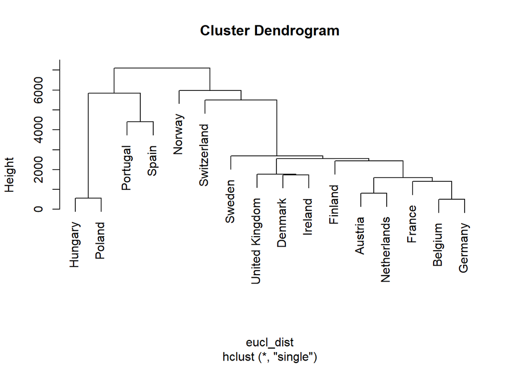

```r
clust_results <- hclust(eucl_dist, method = "single")
plot(clust_results)
```

Try also with different methods (see `?hclust`) an see the differences between dendrograms.

```r
clust_labels_2 <- kmeans(wellbeing2[,-1:-2], 2)$cluster
clust_labels_2
```

```
##        Austria        Belgium        Denmark        Finland         France
##              2              2              2              2              2
##        Germany        Hungary        Ireland    Netherlands         Norway
##              2              1              2              2              2
##         Poland       Portugal          Spain         Sweden    Switzerland
##              1              1              1              2              2
## United Kingdom
##              2
```

```r
clust_labels_3 <- kmeans(wellbeing2[,-1:-2], 3)$cluster
```

The k-means algorithm with 2 clusters separates Hungary, Poland, Portugal and Spain from the rest of the countries. This clustering result might be driven by historical reasons pertaining to these countries.

```r
model1<- lm(wellbeing2$Well.being ~ as.factor(clust_labels_2))
summary(model1)
```

```
##
## Call:
## lm(formula = wellbeing2$Well.being ~ as.factor(clust_labels_2))
##
## Residuals:
##    Min     1Q Median     3Q    Max
## -0.465 -0.230 -0.005  0.150  0.585
##
## Coefficients:
##                            Estimate Std. Error t value Pr(>|t|)
## (Intercept)                  4.9450     0.1556  31.774 1.89e-14 ***
## as.factor(clust_labels_2)2   0.4000     0.1797   2.226    0.043 *
## ---
## Signif. codes:  0 '***' 0.001 '**' 0.01 '*' 0.05 '.' 0.1 ' ' 1
##
## Residual standard error: 0.3113 on 14 degrees of freedom
## Multiple R-squared:  0.2614, Adjusted R-squared:  0.2086
## F-statistic: 4.954 on 1 and 14 DF,  p-value: 0.04297
```